# 01_01B_California_Housing_Map

### 캘리포니아 집값 - 추가 분석 1편 : 지도로 보는 집값

### 학습 내용

- 기본 EDA([01_01_california](https://ldjwj.github.io/dataAnalysis/01_01_california.html))의 위도·경도 산점도를 **지도 분석**으로 확장하기
- 해안·대도시와의 **거리**, 가구당 방 수 같은 **파생 변수** 만들기
- 집값 상한(500,001달러) 같은 **절단(censoring) 현상**을 찾아내고 의미 이해하기

### 내용

- 0. 기본 분석 돌아보기 - 무엇을 보완할까?
- 1. 데이터 준비와 파생 변수
- 2. 정적 지도 - matplotlib 산점도
- 3. 인터랙티브 지도 - plotly
- 4. 해안 거리·위도에 따른 집값
- 5. 대도시(LA, SF)와의 거리와 집값
- 6. 집값 상한 500,001 - 절단 현상
- 7. 파생 변수와 집값의 관계
- 8. 정리

### 0. 기본 분석 돌아보기 - 무엇을 보완할까?

- 기본 분석 결과
  - 학습용 **17,000행**, 테스트용 **3,000행**, 9개 변수(모두 실수형), 결측치 없음
  - 히스토그램/박스플롯으로 분포를 보고, 위도·경도 산점도(색=집값, 크기=인구)를 그렸다.
- 보완할 점
  - 산점도를 그렸지만 **어디가 비싼지, 왜 비싼지** 해석이 없었다. → 해안·대도시 거리로 수치화
  - `total_rooms`, `population`은 블록(구역) 크기에 따라 달라지는 **합계 값** → 가구당 방 수처럼 **비율 변수**가 필요
  - 히스토그램에서 집값 오른쪽 끝에 막대가 튀어 있었지만 설명하지 않았다. → **상한 절단(500,001)** 확인

### 필수 라이브러리 불러오기

```python
import pandas as pd
import numpy as np
import seaborn as sns
import matplotlib.pyplot as plt
import plotly.express as px
import plotly.io as pio
import warnings
warnings.filterwarnings('ignore')

# plotly 그래프가 HTML 파일에 포함되도록 설정
pio.renderers.default = 'notebook'

# 한글 폰트 설정
# - koreanize-matplotlib이 설치되어 있으면 OS와 상관없이 나눔고딕을 사용 (pip install koreanize-matplotlib)
# - 없으면 OS에 맞는 기본 한글 폰트를 사용
try:
    import koreanize_matplotlib
except ImportError:
    import platform
    plt.rcParams['font.family'] = {'Windows': 'Malgun Gothic',
                                   'Darwin': 'AppleGothic'}.get(platform.system(), 'NanumGothic')
plt.rcParams['axes.unicode_minus'] = False

sns.set_theme(style='whitegrid', font=plt.rcParams['font.family'])
```

### 1. 데이터 준비와 파생 변수

- 지도 분석은 **학습용 데이터(train)** 로만 한다. 테스트 데이터는 2편(예측 모델)의 최종 평가용으로 남겨 둔다.

```python
train = pd.read_csv("./data/California/california_housing_train.csv")
test = pd.read_csv("./data/California/california_housing_test.csv")
print(train.shape, test.shape)
train.head(3)
```

```
(17000, 9) (3000, 9)
```

|  | longitude | latitude | housing_median_age | total_rooms | total_bedrooms | population | households | median_income | median_house_value |
| --- | --- | --- | --- | --- | --- | --- | --- | --- | --- |
| 0 | -114.31 | 34.19 | 15.0 | 5612.0 | 1283.0 | 1015.0 | 472.0 | 1.4936 | 66900.0 |
| 1 | -114.47 | 34.40 | 19.0 | 7650.0 | 1901.0 | 1129.0 | 463.0 | 1.8200 | 80100.0 |
| 2 | -114.56 | 33.69 | 17.0 | 720.0 | 174.0 | 333.0 | 117.0 | 1.6509 | 85700.0 |

- 한줄 확인 : 처음 행들의 경도가 -114로 시작한다. 학습 데이터가 **경도 순서(동쪽→서쪽)로 정렬**되어 있다는 뜻 (2편 교차검증에서 중요)

#### 파생 변수 만들기

- 한 행은 집 한 채가 아니라 **블록(block group, 수백~수천 명이 사는 구역)** 이다.
- `total_rooms`(방 합계)는 블록이 크면 커지므로, **가구 수로 나눈 비율**이 집의 특징을 더 잘 나타낸다.

| 파생 변수 | 계산 | 의미 |
| --- | --- | --- |
| rooms_per_household | total_rooms / households | 가구당 방 수 (집 크기) |
| bedrooms_per_room | total_bedrooms / total_rooms | 방 중 침실 비율 |
| population_per_household | population / households | 가구당 인원 |
| house_value_만 | median_house_value / 10000 | 집값(만 달러) - 읽기 쉽게 |

```python
def add_ratio_features(d):
    d = d.copy()
    d['rooms_per_household'] = d['total_rooms'] / d['households']
    d['bedrooms_per_room'] = d['total_bedrooms'] / d['total_rooms']
    d['population_per_household'] = d['population'] / d['households']
    d['house_value_만'] = d['median_house_value'] / 10000
    return d

train = add_ratio_features(train)
train[['rooms_per_household', 'bedrooms_per_room', 'population_per_household']].describe().round(2)
```

|  | rooms_per_household | bedrooms_per_room | population_per_household |
| --- | --- | --- | --- |
| count | 17000.00 | 17000.00 | 17000.00 |
| mean | 5.44 | 0.21 | 2.98 |
| std | 2.54 | 0.06 | 4.04 |
| min | 0.85 | 0.10 | 0.69 |
| 25% | 4.45 | 0.18 | 2.43 |
| 50% | 5.24 | 0.20 | 2.82 |
| 75% | 6.06 | 0.24 | 3.28 |
| max | 141.91 | 1.00 | 502.46 |

- 한줄 확인 : 가구당 방 수 중앙값은 5.24개, 가구당 인원 중앙값은 2.82명이다.
  - 최댓값(방 141.9개, 인원 502.5명)은 리조트·기숙사·교도소처럼 **특수한 블록**으로 보이는 이상치다.

#### 거리 변수 만들기 - 대도시, 해안

- 두 지점 사이의 거리는 위도·경도로 **하버사인(haversine) 공식**을 써서 km로 계산한다.
- 대도시 좌표 : 로스앤젤레스(LA) (34.05, -118.24), 샌프란시스코(SF) (37.77, -122.42)
- 해안선은 데이터에 없으므로, 북쪽 크레센트시티부터 남쪽 샌디에이고까지 **해안 도시 24곳의 좌표를 이어 만든 근사 해안선**을 사용한다.
  - 샌프란시스코만(bay) 안쪽은 해안선에 포함하지 않았으므로 오클랜드 등은 실제보다 해안 거리가 조금 멀게 계산된다.

```python
def haversine(lat1, lon1, lat2, lon2):
    # 위도/경도(도) → 거리(km)
    lat1, lon1, lat2, lon2 = map(np.radians, [lat1, lon1, lat2, lon2])
    a = np.sin((lat2 - lat1) / 2)**2 + np.cos(lat1) * np.cos(lat2) * np.sin((lon2 - lon1) / 2)**2
    return 6371 * 2 * np.arcsin(np.sqrt(a))

CITIES = {'LA': (34.05, -118.24), 'SF': (37.77, -122.42)}

# 근사 해안선 (북 → 남, 위도, 경도)
COAST = np.array([
    (41.75, -124.20), (40.80, -124.16), (40.44, -124.40), (39.45, -123.80),
    (38.91, -123.71), (38.33, -123.05), (38.00, -123.00), (37.76, -122.51),
    (37.46, -122.44), (36.96, -122.02), (36.60, -121.89), (36.27, -121.81),
    (35.64, -121.19), (35.37, -120.85), (34.45, -120.47), (34.41, -119.69),
    (34.27, -119.29), (34.03, -118.78), (34.01, -118.50), (33.76, -118.19),
    (33.60, -117.90), (33.19, -117.38), (32.72, -117.17), (32.58, -117.13)])

# 해안 도시 사이를 촘촘한 점(약 1km 간격)으로 채워서 '선'처럼 만들기
coast_pts = np.vstack([np.linspace(COAST[i], COAST[i + 1], 100) for i in range(len(COAST) - 1)])

def add_distance_features(d):
    d = d.copy()
    for name, (lat, lon) in CITIES.items():
        d[f'dist_{name}'] = haversine(d['latitude'], d['longitude'], lat, lon)
    d['dist_city'] = d[['dist_LA', 'dist_SF']].min(axis=1)   # 가까운 대도시까지 거리
    # 각 블록에서 해안선 점까지의 거리 중 최솟값
    dist = haversine(d['latitude'].values[:, None], d['longitude'].values[:, None],
                     coast_pts[:, 0][None, :], coast_pts[:, 1][None, :])
    d['dist_coast'] = dist.min(axis=1)
    return d

train = add_distance_features(train)
train[['dist_LA', 'dist_SF', 'dist_city', 'dist_coast']].describe().round(1)
```

|  | dist_LA | dist_SF | dist_city | dist_coast |
| --- | --- | --- | --- | --- |
| count | 17000.0 | 17000.0 | 17000.0 | 17000.0 |
| mean | 269.0 | 386.9 | 89.7 | 51.9 |
| std | 248.0 | 249.9 | 84.2 | 59.0 |
| min | 0.0 | 0.0 | 0.0 | 0.0 |
| 25% | 32.0 | 117.1 | 22.9 | 11.6 |
| 50% | 172.8 | 526.3 | 57.8 | 25.7 |
| 75% | 526.6 | 584.1 | 139.8 | 72.2 |
| max | 1018.6 | 899.7 | 489.6 | 341.7 |

- 한줄 확인 : 블록의 절반은 가까운 대도시에서 57.8 km 이내, 해안에서 25.7 km 이내에 있다. 인구가 해안 대도시에 몰려 있다.

### 2. 정적 지도 - matplotlib 산점도

- 기본 분석의 산점도에 **대도시 위치와 해안선**을 함께 표시하고, 집값과 소득을 나란히 비교한다.
- 색 : `viridis`(어두운 보라=낮음 → 노랑=높음), 점 크기 : 인구

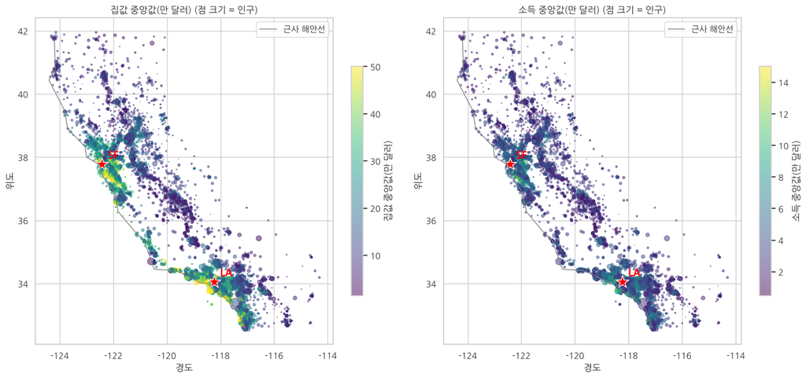

```python
fig, axes = plt.subplots(1, 2, figsize=(15, 7))
for ax, col, title in zip(axes, ['house_value_만', 'median_income'],
                          ['집값 중앙값(만 달러)', '소득 중앙값(만 달러)']):
    sc = ax.scatter(train['longitude'], train['latitude'], c=train[col], cmap='viridis',
                    s=train['population'] / 150, alpha=0.5)
    ax.plot(COAST[:, 1], COAST[:, 0], color='gray', lw=1, label='근사 해안선')
    for name, (lat, lon) in CITIES.items():
        ax.scatter(lon, lat, marker='*', s=300, color='red', edgecolor='white')
        ax.annotate(name, (lon, lat), xytext=(8, 8), textcoords='offset points',
                    fontsize=13, color='red', fontweight='bold')
    fig.colorbar(sc, ax=ax, shrink=0.7, label=title)
    ax.set_title(title + ' (점 크기 = 인구)')
    ax.set_xlabel('경도'); ax.set_ylabel('위도')
    ax.legend(loc='upper right')
plt.tight_layout()
plt.show()
```

- 한줄 확인 : 밝은(비싼) 점은 **LA·SF 주변의 해안**에 몰려 있고, 내륙(센트럴 밸리, 동쪽 사막)은 어둡다.
  - 소득 지도와 집값 지도의 밝은 지역이 거의 겹친다 → 소득이 집값의 가장 큰 설명 변수일 가능성

### 3. 인터랙티브 지도 - plotly

- `px.scatter_map` : 실제 지도 위에 점을 찍는다(OpenStreetMap 계열 타일, 토큰 불필요). 마우스를 올리면 값이 보인다.
- 17,000개를 모두 넣으면 HTML이 무거워지므로 **5,000개를 표본 추출**한다.

```python
sample = train.sample(5000, random_state=42)

fig = px.scatter_map(sample, lat='latitude', lon='longitude',
                     color='house_value_만', size='population', size_max=12,
                     color_continuous_scale='Viridis', opacity=0.6,
                     hover_data={'house_value_만': ':.1f', 'median_income': ':.2f',
                                 'dist_coast': ':.0f', 'population': True,
                                 'latitude': False, 'longitude': False},
                     labels={'house_value_만': '집값(만$)', 'median_income': '소득(만$)',
                             'dist_coast': '해안거리(km)', 'population': '인구'},
                     zoom=4.8, center={'lat': 36.8, 'lon': -119.4},
                     map_style='carto-positron', height=650,
                     title='캘리포니아 블록별 집값 (표본 5,000개)')
fig.update_layout(margin=dict(l=0, r=0, t=40, b=0))
fig.show()
```

[interactive chart not shown]

- 한줄 확인 : 정적 지도와 같이 LA·SF 주변 해안에 노란(비싼) 점이 모여 있다. 마우스로 확대(스크롤)해서 동네 단위로 직접 확인해 보자.

#### 밀도 지도 - 어디에 블록이 많을까?

- `px.density_map`은 점이 겹치는 정도(밀도)를 색으로 보여 준다. `z`에 집값을 넣으면 **비싼 블록이 몰린 곳**이 진하게 표시된다.

```python
fig = px.density_map(sample, lat='latitude', lon='longitude', z='house_value_만', radius=6,
                     zoom=4.8, center={'lat': 36.8, 'lon': -119.4},
                     map_style='carto-positron', height=600,
                     color_continuous_scale='Inferno',
                     title='집값 가중 밀도 지도 (표본 5,000개)')
fig.update_layout(margin=dict(l=0, r=0, t=40, b=0))
fig.show()
```

[interactive chart not shown]

- 한줄 확인 : 블록이 많이 모여 있고 집값도 높은 곳일수록 진하게 보인다. 2장의 정적 지도에서 비싼 블록이 몰려 있던 **LA·SF 대도시권**이 여기에 해당한다.

### 4. 해안 거리·위도에 따른 집값

- 해안 거리를 구간으로 나누고 구간별 **집값 중앙값과 블록 수**를 함께 본다.

```python
coast_bins = [0, 10, 25, 50, 100, 200, 500]
coast_labels = ['0~10', '10~25', '25~50', '50~100', '100~200', '200~500']
train['coast_band'] = pd.cut(train['dist_coast'], bins=coast_bins, labels=coast_labels, include_lowest=True)

coast_tbl = train.groupby('coast_band', observed=True).agg(
    블록수=('house_value_만', 'size'),
    집값중앙값_만=('house_value_만', 'median'),
    소득중앙값_만=('median_income', 'median'))
coast_tbl.round(1)
```

| coast_band | 블록수 | 집값중앙값_만 | 소득중앙값_만 |
| --- | --- | --- | --- |
| 0~10 | 3791 | 25.1 | 3.8 |
| 10~25 | 4511 | 20.8 | 3.7 |
| 25~50 | 3505 | 20.8 | 4.0 |
| 50~100 | 1588 | 13.0 | 3.4 |
| 100~200 | 3295 | 9.3 | 2.7 |
| 200~500 | 310 | 10.4 | 2.8 |

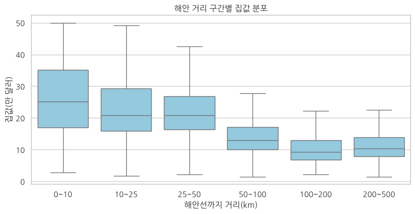

```python
fig, ax = plt.subplots(figsize=(10, 4.5))
sns.boxplot(data=train, x='coast_band', y='house_value_만', color='skyblue',
            showfliers=False, ax=ax)
ax.set_title('해안 거리 구간별 집값 분포')
ax.set_xlabel('해안선까지 거리(km)'); ax.set_ylabel('집값(만 달러)')
plt.show()
```

- 한줄 확인 : 해안 10km 이내 블록의 집값 중앙값은 **25.1만 달러**, 100~200km 구간은 **9.3만 달러**로 약 2.7배 차이
  - 다만 소득도 3.8 → 2.7(만 달러)로 함께 낮아진다. 해안 효과의 일부는 소득 차이 때문이다.
  - 200~500km 구간(310개)은 10.4만 달러로 100~200km보다 약간 높다. 동쪽 산악·사막 지역(리조트 등)이 섞인 것으로 보인다.

#### 위도별 집값 - 남북으로 어떻게 달라질까?

- 위도를 0.5도(약 55km) 단위로 묶어 중앙값을 보고, 해안 25km 이내/밖으로 나누어 비교한다.

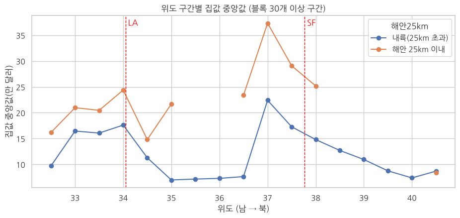

| lat_band 해안25km | 32.5 | 33.0 | 33.5 | 34.0 | 34.5 | 35.0 | 35.5 | 36.0 | 36.5 | 37.0 | 37.5 | 38.0 | 38.5 | 39.0 | 39.5 | 40.0 | 40.5 |
| --- | --- | --- | --- | --- | --- | --- | --- | --- | --- | --- | --- | --- | --- | --- | --- | --- | --- |
| 내륙(25km 초과) | 9.7 | 16.4 | 16.1 | 17.6 | 11.3 | 7.0 | 7.2 | 7.3 | 7.6 | 22.4 | 17.3 | 14.8 | 12.7 | 10.9 | 8.8 | 7.4 | 8.7 |
| 해안 25km 이내 | 16.2 | 21.0 | 20.5 | 24.4 | 14.8 | 21.7 | NaN | NaN | 23.4 | 37.3 | 29.1 | 25.2 | NaN | NaN | NaN | NaN | 8.4 |

```python
train['lat_band'] = (train['latitude'] // 0.5) * 0.5
train['해안25km'] = np.where(train['dist_coast'] <= 25, '해안 25km 이내', '내륙(25km 초과)')

lat_tbl = train.groupby(['lat_band', '해안25km'])['house_value_만'].agg(['median', 'size']).reset_index()
lat_tbl = lat_tbl[lat_tbl['size'] >= 30]   # 블록 30개 미만 구간은 제외(값이 불안정)
lat_pivot = lat_tbl.pivot(index='lat_band', columns='해안25km', values='median')

# 값이 없는 구간(NaN)은 선이 끊어지도록 pivot 표로 그린다
fig, ax = plt.subplots(figsize=(11, 4.5))
lat_pivot.plot(marker='o', ax=ax)
for name, (lat, lon) in CITIES.items():
    ax.axvline(lat, color='red', ls='--', lw=1)
    ax.text(lat + 0.05, ax.get_ylim()[1] * 0.95, name, color='red')
ax.set_title('위도 구간별 집값 중앙값 (블록 30개 이상 구간)')
ax.set_xlabel('위도 (남 → 북)'); ax.set_ylabel('집값 중앙값(만 달러)')
plt.show()

lat_pivot.round(1).T
```

- 한줄 확인 : 두 그룹이 모두 30개 이상인 위도 구간에서는 40.5도(북쪽 끝, 해안 8.4 vs 내륙 8.7)를 빼고 **모두 해안 쪽이 비싸다.**
  - 해안 블록은 위도 37.0도(실리콘밸리·SF 반도)에서 **37.3만 달러**로 가장 높고, 내륙도 같은 37.0도에서 22.4만 달러로 가장 높다.
  - 위도 35.0~36.5도 내륙(센트럴 밸리)은 7.0~7.6만 달러로 가장 싸다. 즉, 위도 자체보다 **대도시권이냐 아니냐**가 중요하다.

### 5. 대도시(LA, SF)와의 거리와 집값

- 가까운 대도시(LA 또는 SF)까지의 거리 구간별 집값을 본다.
- 거리가 멀어질수록 소득도 함께 낮아지는지(혼재 변수) 같이 확인한다.

```python
city_bins = [0, 25, 50, 100, 200, 400, 800]
city_labels = ['0~25', '25~50', '50~100', '100~200', '200~400', '400~800']
train['city_band'] = pd.cut(train['dist_city'], bins=city_bins, labels=city_labels, include_lowest=True)
train['가까운도시'] = np.where(train['dist_LA'] <= train['dist_SF'], 'LA', 'SF')

city_tbl = train.groupby(['가까운도시', 'city_band'], observed=True).agg(
    블록수=('house_value_만', 'size'),
    집값중앙값_만=('house_value_만', 'median'),
    소득중앙값_만=('median_income', 'median')).round(1)
city_tbl
```

| 가까운도시 | city_band | 블록수 | 집값중앙값_만 | 소득중앙값_만 |
| --- | --- | --- | --- | --- |
| LA | 0~25 | 3350 | 19.8 | 3.2 |
|  | 25~50 | 2206 | 21.6 | 4.3 |
|  | 50~100 | 1673 | 18.4 | 4.1 |
|  | 100~200 | 2133 | 15.4 | 3.3 |
|  | 200~400 | 637 | 8.6 | 2.6 |
| SF | 0~25 | 1313 | 26.2 | 3.6 |
|  | 25~50 | 969 | 25.0 | 4.8 |
|  | 50~100 | 1520 | 23.3 | 4.4 |
|  | 100~200 | 2006 | 12.2 | 3.0 |
|  | 200~400 | 1145 | 8.6 | 2.6 |
|  | 400~800 | 48 | 6.3 | 2.2 |

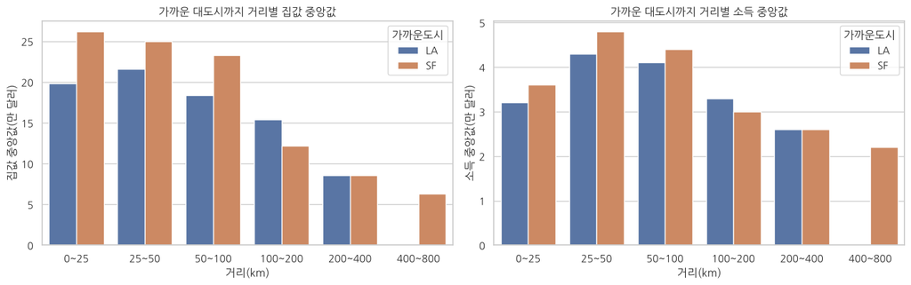

```python
fig, axes = plt.subplots(1, 2, figsize=(14, 4.5))
for ax, col, title in zip(axes, ['집값중앙값_만', '소득중앙값_만'], ['집값 중앙값', '소득 중앙값']):
    sns.barplot(data=city_tbl.reset_index(), x='city_band', y=col, hue='가까운도시', ax=ax)
    ax.set_title(f'가까운 대도시까지 거리별 {title}')
    ax.set_xlabel('거리(km)'); ax.set_ylabel(title + '(만 달러)')
plt.tight_layout()
plt.show()
```

- 한줄 확인 : SF 쪽은 25km 이내가 **26.2만 달러**로 가장 높고 거리가 멀수록 낮아진다. 200km를 넘으면 LA·SF 모두 8.6만 달러
  - LA 쪽은 25km 이내(19.8)보다 25~50km(21.6)가 더 비싸다. 오른쪽 그림처럼 LA 도심 25km 이내의 **소득 중앙값(3.2)이 25~50km(4.3)보다 낮기** 때문이다.

#### 같은 소득이라면 대도시와 가까울수록 비쌀까?

- 소득을 4개 구간(사분위)으로 나눈 뒤, 같은 소득 구간 안에서 거리별 집값을 비교한다.

```python
train['income_q'] = pd.qcut(train['median_income'], 4, labels=['소득 하위25%', '25~50%', '50~75%', '소득 상위25%'])
pivot = train.pivot_table(index='income_q', columns='city_band', values='house_value_만',
                          aggfunc='median', observed=True).round(1)
pivot
```

| city_band income_q | 0~25 | 25~50 | 50~100 | 100~200 | 200~400 | 400~800 |
| --- | --- | --- | --- | --- | --- | --- |
| 소득 하위25% | 14.4 | 15.5 | 10.8 | 9.3 | 6.8 | 6.1 |
| 25~50% | 19.5 | 18.1 | 14.7 | 12.8 | 9.3 | 8.1 |
| 50~75% | 25.1 | 20.0 | 19.4 | 16.1 | 12.0 | NaN |
| 소득 상위25% | 37.6 | 29.8 | 28.5 | 24.8 | 16.0 | NaN |

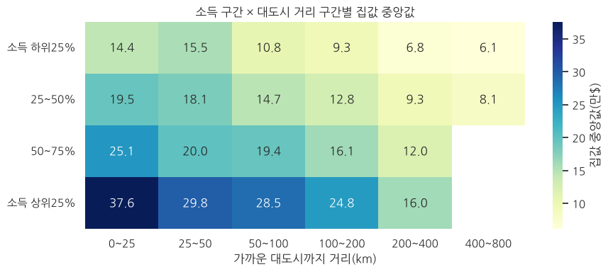

```python
fig, ax = plt.subplots(figsize=(10, 3.8))
sns.heatmap(pivot, annot=True, fmt='.1f', cmap='YlGnBu', cbar_kws={'label': '집값 중앙값(만$)'}, ax=ax)
ax.set_title('소득 구간 × 대도시 거리 구간별 집값 중앙값')
ax.set_xlabel('가까운 대도시까지 거리(km)'); ax.set_ylabel('')
ax.grid(False)
plt.show()
```

- 한줄 확인 : 같은 소득 구간 안에서도 대도시에서 멀어질수록 집값이 낮아진다. 소득 상위 25%는 25km 이내 **37.6만** → 200~400km **16.0만 달러**
  - 예외는 소득 하위 25%의 0~25km(14.4) < 25~50km(15.5) 정도이다. 소득을 맞춰도 **거리 효과가 남는다** → 예측 모델에 넣을 가치가 있는 변수

### 6. 집값 상한 500,001 - 절단 현상

- 기본 분석의 히스토그램 오른쪽 끝에 막대가 튀어 있었다. 실제 값을 확인해 보자.

```python
cap = train['median_house_value'].max()
n_cap = (train['median_house_value'] == cap).sum()
print(f'집값 최댓값 : {cap:,.0f}달러')
print(f'최댓값과 같은 블록 : {n_cap}개 ({n_cap / len(train):.1%})')
print('두 번째로 큰 값 :', f"{train.loc[train['median_house_value'] < cap, 'median_house_value'].max():,.0f}달러")

# 다른 변수에도 상한이 있을까?
for col in ['housing_median_age', 'median_income']:
    mx = train[col].max()
    print(f'{col} 최댓값 {mx} → {(train[col] == mx).sum()}개')
```

```
집값 최댓값 : 500,001달러
최댓값과 같은 블록 : 814개 (4.8%)
두 번째로 큰 값 : 500,000달러
housing_median_age 최댓값 52.0 → 1052개
median_income 최댓값 15.0001 → 38개
```

- 한줄 확인 : 집값 최댓값 500,001달러인 블록이 **814개(4.8%)** 이고, 바로 아래 값은 500,000달러이다.
  - 1990년 인구조사에서 **50만 달러 이상은 모두 '500,001'로 기록**했기 때문이다(top-coding, 상한 절단). 실제로는 100만 달러짜리 동네도 500,001로 적혀 있다.
  - `housing_median_age`(52년), `median_income`(15.0001)에도 같은 상한이 있다.

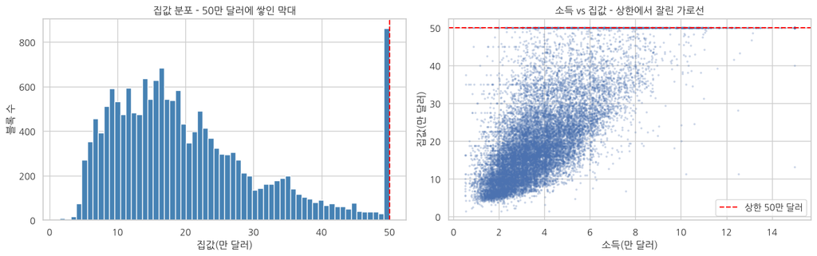

```python
fig, axes = plt.subplots(1, 2, figsize=(14, 4.5))

axes[0].hist(train['house_value_만'], bins=60, color='steelblue')
axes[0].axvline(50, color='red', ls='--')
axes[0].set_title('집값 분포 - 50만 달러에 쌓인 막대')
axes[0].set_xlabel('집값(만 달러)'); axes[0].set_ylabel('블록 수')

axes[1].scatter(train['median_income'], train['house_value_만'], s=3, alpha=0.2)
axes[1].axhline(50, color='red', ls='--', label='상한 50만 달러')
axes[1].set_title('소득 vs 집값 - 상한에서 잘린 가로선')
axes[1].set_xlabel('소득(만 달러)'); axes[1].set_ylabel('집값(만 달러)')
axes[1].legend()
plt.tight_layout()
plt.show()
```

- 한줄 확인 : 오른쪽 그림에서 점들이 50만 달러 위로 올라가지 못하고 **가로선**에 붙어 있다. 소득이 높을수록 이 선에 걸리는 비율이 높다.

```python
capped = train['median_house_value'] == cap
train['상한'] = capped
# 구간별 상한 블록 비율(%)
display(train.groupby('coast_band', observed=True)['상한'].mean().mul(100).round(1)
        .to_frame('상한 비율(%) - 해안 거리(km)별').T)
display(train.groupby('income_q', observed=True)['상한'].mean().mul(100).round(1)
        .to_frame('상한 비율(%) - 소득 구간별').T)
```

| coast_band | 0~10 | 10~25 | 25~50 | 50~100 | 100~200 | 200~500 |
| --- | --- | --- | --- | --- | --- | --- |
| 상한 비율(%) - 해안 거리(km)별 | 10.4 | 7.0 | 2.7 | 0.3 | 0.1 | 0.3 |

| income_q | 소득 하위25% | 25~50% | 50~75% | 소득 상위25% |
| --- | --- | --- | --- | --- |
| 상한 비율(%) - 소득 구간별 | 0.5 | 0.9 | 2.5 | 15.3 |

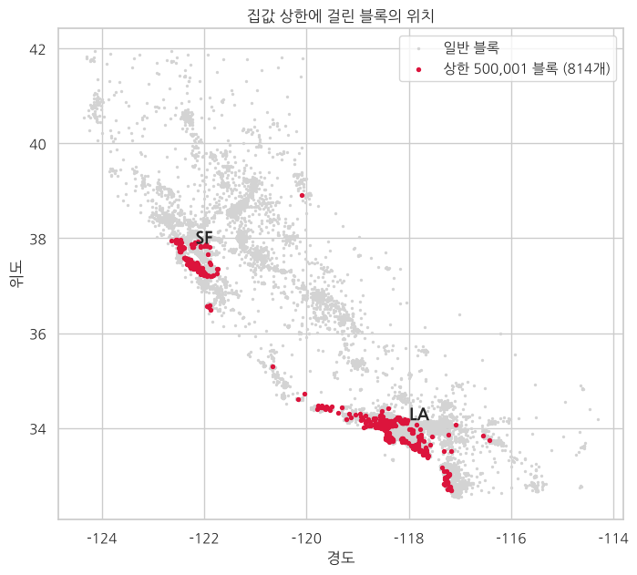

```python
fig, ax = plt.subplots(figsize=(8, 7))
ax.scatter(train['longitude'], train['latitude'], s=2, color='lightgray', label='일반 블록')
ax.scatter(train.loc[capped, 'longitude'], train.loc[capped, 'latitude'], s=8, color='crimson',
           label=f'상한 500,001 블록 ({capped.sum()}개)')
for name, (lat, lon) in CITIES.items():
    ax.annotate(name, (lon, lat), xytext=(10, 5), textcoords='offset points', fontsize=13, fontweight='bold')
ax.set_title('집값 상한에 걸린 블록의 위치')
ax.set_xlabel('경도'); ax.set_ylabel('위도')
ax.legend()
plt.show()
```

- 한줄 확인 : 상한 블록은 거의 모두 **SF 베이 지역과 LA~샌디에이고 해안**에 있다. 위 표에서도 해안 10km 이내는 10.4%, 100~200km는 0.1%가 상한이고, 소득 상위 25%는 15.3%, 하위 25%는 0.5%다.
  - **의미** : 비싼 동네의 집값은 실제보다 낮게 기록되어 있다. 평균·상관계수가 과소 추정되고, 예측 모델은 비싼 지역에서 오차가 커진다(2편에서 확인).

### 7. 파생 변수와 집값의 관계

- 원래 변수와 파생 변수의 **상관계수**를 비교한다. 이상치 영향을 줄이기 위해 순위 기반 **스피어만 상관계수**도 함께 본다.

```python
cols = ['median_income', 'total_rooms', 'population', 'households', 'housing_median_age',
        'rooms_per_household', 'bedrooms_per_room', 'population_per_household',
        'latitude', 'longitude', 'dist_city', 'dist_coast']
corr = pd.DataFrame({
    '피어슨': train[cols].corrwith(train['median_house_value']),
    '스피어만': train[cols].corrwith(train['median_house_value'], method='spearman')})
corr.sort_values('스피어만', key=abs, ascending=False).round(3)
```

|  | 피어슨 | 스피어만 |
| --- | --- | --- |
| median_income | 0.692 | 0.681 |
| dist_coast | -0.493 | -0.536 |
| dist_city | -0.435 | -0.451 |
| bedrooms_per_room | -0.258 | -0.336 |
| rooms_per_household | 0.150 | 0.265 |
| population_per_household | -0.043 | -0.258 |
| total_rooms | 0.131 | 0.204 |
| latitude | -0.145 | -0.168 |
| households | 0.061 | 0.109 |
| housing_median_age | 0.107 | 0.076 |
| longitude | -0.045 | -0.070 |
| population | -0.028 | -0.001 |

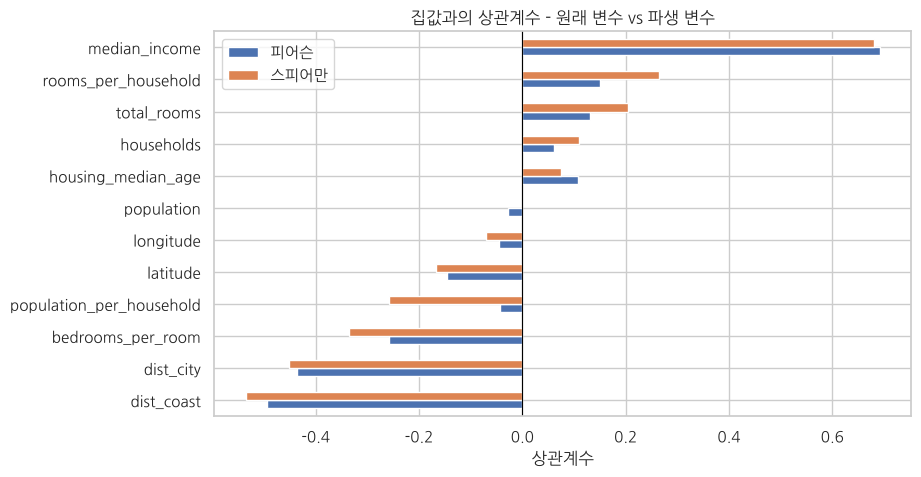

```python
fig, ax = plt.subplots(figsize=(9, 5))
corr.sort_values('스피어만').plot.barh(ax=ax)
ax.axvline(0, color='black', lw=0.8)
ax.set_title('집값과의 상관계수 - 원래 변수 vs 파생 변수')
ax.set_xlabel('상관계수')
plt.show()
```

- 한줄 확인 : 소득(0.692)이 가장 강하고, 그다음이 새로 만든 **해안 거리(-0.493, 스피어만 -0.536)** 와 **대도시 거리(-0.435)** 이다. 원래 위도(-0.145)·경도(-0.045)보다 훨씬 강하다.
  - 비율 변수도 효과가 있다. 스피어만 기준 `population`(-0.001) → `population_per_household`(-0.258), `total_rooms`(0.204) → `rooms_per_household`(0.265)
  - 침실 비율 `bedrooms_per_room`(-0.336)은 음의 관계 : 방 중에 침실 비율이 높으면(작은 집) 싸다.
  - 피어슨과 스피어만 차이가 큰 변수(가구당 인원 -0.043 vs -0.258)는 **이상치** 때문에 피어슨이 약해진 경우이다.

### 8. 정리

| 질문 | 기본 분석 | 추가 분석 결과 |
| --- | --- | --- |
| 비싼 곳은 어디? | 산점도만 그림 | **LA·SF 주변 해안**. 해안 10km 이내 중앙값 25.1만 vs 100~200km 9.3만 달러 |
| 위도(남북)가 중요한가? | 위도 범위(32.5~42도)만 확인 | 위도 자체보다 대도시권 여부. 해안 블록은 37.0도(실리콘밸리)가 37.3만 달러로 최고, 센트럴 밸리 내륙은 7만 달러대 |
| 대도시와 가까우면 비싼가? | - | 그렇다. 소득을 같은 구간으로 맞춰도 거리 효과가 남음(소득 상위 25%: 37.6만 → 16.0만) |
| 집값 분포 끝의 막대는? | 설명 없음 | **500,001 상한 절단** 814개(4.8%). 해안·고소득 지역에 몰림 (소득 상위 25%의 15.3%) |
| 어떤 변수가 집값과 관련 있나? | - | 소득(0.69) > 해안 거리(-0.49) > 대도시 거리(-0.44). 비율 변수가 합계 변수보다 관계가 뚜렷함 |

#### 배운 점

- 위도·경도는 그대로 두면 숫자일 뿐이지만, **기준점(해안, 대도시)까지의 거리**로 바꾸면 해석 가능한 변수가 된다.
- 합계 변수(방 수, 인구)는 블록 크기의 영향을 받으므로 **가구당 비율**로 바꿔서 본다.
- 분포 끝에 값이 쌓여 있으면 **상한 절단(top-coding)** 을 의심하고, 결과 해석에 반영한다.
- 지역별 차이는 **소득 같은 혼재 변수**를 같은 구간으로 맞춘 뒤 비교해야 정확하다.

#### 다음에 해 볼 분석

- 2편 [01_01C_California_Housing_Model](https://ldjwj.github.io/dataAnalysis/01_01C_California_Housing_Model.html) : 이 파생 변수들을 넣어 **집값 예측 모델**(선형 회귀, 랜덤포레스트, 그래디언트 부스팅)을 만들고 효과를 측정한다.